# Comparing validation methods

me

4 joulukuuta 2019

# 2. Validointimetodien vertailu

Verrataan neljällä eri metodilla laskettuja ennustustarkkuuksia.  
Onko validointimetodien välillä eroja? (vaikuttaako metodi ennustustarkkuuteen?) Onko ennustaminen helpompaa pa vai abu-aineistolla? (vaikuttaako aineistotyyppi ennustustarkkuuteen?) Kullakin lajilla ennustaminen voi olla ylipäätään helpompaa tai vaikeampaa, metodista tai aineistotyypistä riippumatta. (laji huomioitava random-muuttujana)

Luetaan edellisessä osiossa lasketut tulokset sisälle:

```r
getwd()
```

```
## [1] "C:/Users/Sirke Piirainen/OneDrive - University of Helsinki/github_mallinnus/model_validation"
```

```r
res<-read.csv("results.csv",header=T,sep=",")
str(res)
```

```
## 'data.frame':    120 obs. of  10 variables:
##  $ species: Factor w/ 120 levels "Acrocephalus_palustris",..: 1 2 3 4 5 6 7 8 9 10 ...
##  $ pa_A   : num  0.62 0.377 0.514 0.167 0.364 ...
##  $ pa_B   : num  0.609 0.362 0.465 0.11 0.35 ...
##  $ pa_C   : num  0.2778 0.0547 -0.1763 0.0842 -0.0384 ...
##  $ pa_D   : num  0.2621 0.0572 -0.1937 -0.0759 -0.0582 ...
##  $ abu_A  : num  0.525 0.232 0.316 0.292 0.402 ...
##  $ abu_B  : num  0.3938 0.1387 0.094 0.0593 0.2075 ...
##  $ abu_C  : num  0.1192 0.2488 -0.1396 -0.0582 0.373 ...
##  $ abu_D  : num  0.227 0.151 -0.137 -0.134 -0.497 ...
##  $ P_D    : int  25 23 37 60 12 83 19 91 29 86 ...
```

Testaan, miten tulokset muuttuvat jos abu-aineistosta karsitaan pois muutamat havainnot, jotka perustuvat vain alle kymmeneen havaintoon. Tätä rajaa voidaan testailla.

```r
sort(res$P_D)
```

```
##   [1]   3   4  10  10  11  12  12  13  14  15  15  16  17  17  19  19  20
##  [18]  21  22  22  23  25  25  27  27  29  29  29  31  32  32  32  32  34
##  [35]  34  35  35  37  37  38  39  42  43  43  43  44  47  47  52  54  58
##  [52]  60  61  61  62  62  63  65  66  72  73  73  75  76  79  81  83  83
##  [69]  84  86  87  87  88  89  91  91  92  92  93 100 104 104 107 108 110
##  [86] 112 112 118 119 119 119 120 127 130 133 135 143 146 147 148 150 151
## [103] 159 159 160 163 164 166 179 182 193 196 196 207 214 218 224 224 231
## [120] 262
```

```r
res$abu_D[res$P_D<10]=NA
res$abu_C[res$P_D<10]=NA
```

Jos minimihavaintorajana pidetään kymmentä, **pohjansirkku ja pyy putoavat pois** (muuttuvat NA:ksi). Tarkistan NA-havaintojen määrät jokaiselle metodille.

```r
sum(is.na(res$pa_A))
```

```
## [1] 0
```

```r
sum(is.na(res$pa_B))
```

```
## [1] 0
```

```r
sum(is.na(res$pa_C))
```

```
## [1] 0
```

```r
sum(is.na(res$pa_D))
```

```
## [1] 0
```

```r
sum(is.na(res$abu_A))
```

```
## [1] 0
```

```r
sum(is.na(res$abu_B))
```

```
## [1] 0
```

```r
sum(is.na(res$abu_C))
```

```
## [1] 2
```

```r
sum(is.na(res$abu_D))
```

```
## [1] 2
```

Eli aineisto ei ole enää ihan täydellisen balanssissa. Pohjansirkulta ja pyyltä puuttuvat arvot abu-aineistosta C ja D menetelmille.

## 2.1 Keskiarvot ja keskivirheet

Lasketaan ennustustarkkuuksien keskiarvot ja keskivirheet kullekin metodi/aineistotyyppi-yhdistelmälle:

```r
#Compute means and standard errors
knitr::kable(res %>% dplyr::select(2:9)%>%colMeans(.,na.rm = T),digits=3)
```

|  | x |
| --- | --- |
| pa_A | 0.575 |
| pa_B | 0.536 |
| pa_C | 0.023 |
| pa_D | 0.024 |
| abu_A | 0.405 |
| abu_B | 0.313 |
| abu_C | 0.012 |
| abu_D | 0.003 |

```r
knitr::kable(res %>% dplyr::select(2:9)%>%std.error(),digits=3)
```

|  | x |
| --- | --- |
| pa_A | 0.015 |
| pa_B | 0.016 |
| pa_C | 0.013 |
| pa_D | 0.012 |
| abu_A | 0.015 |
| abu_B | 0.017 |
| abu_C | 0.017 |
| abu_D | 0.017 |

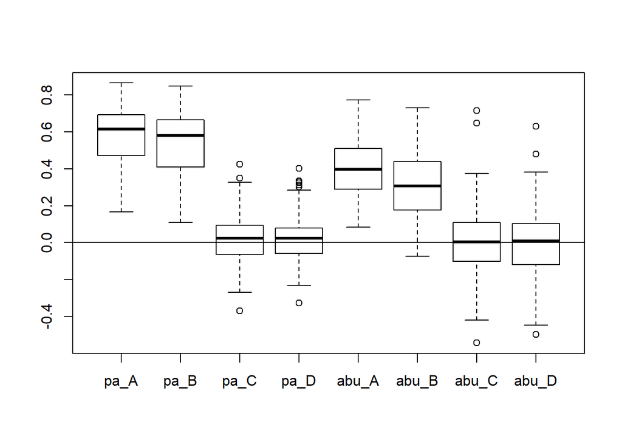

```r
#aineiston jakauma, boxplot
boxplot(res[c(-1,-10)])
abline(h=0)
```

Pitäisikö kuvaajissa pitää pa ja abu erillään?

## 2.2 Analyysit

### 2.2.1 Aineiston muokkaus

Mallintamista varten luodaan uusi muuttuja, joka kertoo onko käytetty aineisto pa- vai abu-aineistoa. Muutan myös method-muuttujan koodausta hieman.

```r
#aineiston muokkaus:
res_pa=res[,1:5]
res_pa=gather(res_pa,"method","accuracy",2:5)
res_pa$method=as.factor(revalue(res_pa$method,c("pa_A"="A","pa_B"="B","pa_C"="C","pa_D"="D")))
res_pa$pa=as.factor("pa")

res_abu=res[,c(1,6:9)]
res_abu=gather(res_abu,"method","accuracy",2:5)
res_abu$method=as.factor(revalue(res_abu$method,c("abu_A"="A","abu_B"="B","abu_C"="C","abu_D"="D")))
res_abu$pa=as.factor("abu")

res2=rbind(res_abu,res_pa)
str(res2)
```

```
## 'data.frame':    960 obs. of  4 variables:
##  $ species : Factor w/ 120 levels "Acrocephalus_palustris",..: 1 2 3 4 5 6 7 8 9 10 ...
##  $ method  : Factor w/ 4 levels "A","B","C","D": 1 1 1 1 1 1 1 1 1 1 ...
##  $ accuracy: num  0.525 0.232 0.316 0.292 0.402 ...
##  $ pa      : Factor w/ 2 levels "abu","pa": 1 1 1 1 1 1 1 1 1 1 ...
```

```r
summary(res2)
```

```
##                        species    method     accuracy          pa
##  Acrocephalus_palustris    :  8   A:240   Min.   :-0.54281   abu:480
##  Acrocephalus_schoenobaenus:  8   B:240   1st Qu.: 0.01376   pa :480
##  Acrocephalus_scirpaceus   :  8   C:240   Median : 0.20046
##  Actitis_hypoleucos        :  8   D:240   Mean   : 0.23727
##  Aegithalos_caudatus       :  8           3rd Qu.: 0.46495
##  Alauda_arvensis           :  8           Max.   : 0.86391
##  (Other)                   :912           NA's   :4
```

```r
#tallennetaan taulukko, muista, että mukana NA:ta!!
write.csv(res2,"results_with_NA.csv",row.names = F)
```

Teen uuden kuvaajan tällä aineistolla.

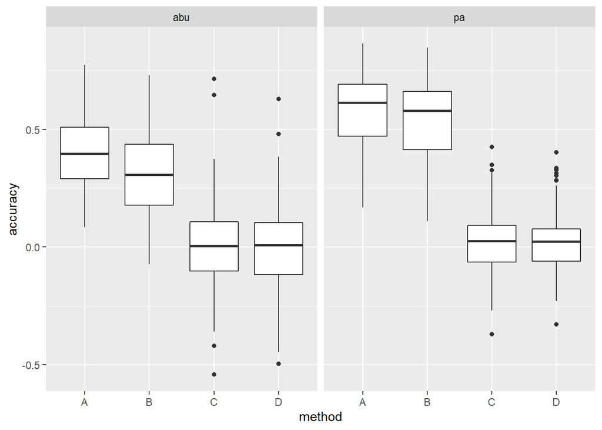

```r
ggplot(res2,aes(x=method, y=accuracy))+geom_boxplot()+facet_grid(.~pa)
```

### 2.2.2 Lineaarinen sekamalli

Alkuperäinen idea oli käyttää lineaarista sekamuuttujamallia, jossa ennustustarkkuutta selittävät metodi ja aineistotyyppi sekä niiden välinen interaktio. Lisäksi malli huomioi lajin random-tekijänä.

Aloitan kuitenkin harjoituksen vuoksi ensin ihan perus lineaarisella mallilla, ilman random-tekijää.

```r
m0=lm(accuracy~method*pa,data=res2,na.action = "na.exclude")
summary(m0)
```

```
##
## Call:
## lm(formula = accuracy ~ method * pa, data = res2, na.action = "na.exclude")
##
## Residuals:
##      Min       1Q   Median       3Q      Max
## -0.55480 -0.10613  0.00126  0.10766  0.70239
##
## Coefficients:
##              Estimate Std. Error t value Pr(>|t|)
## (Intercept)   0.40547    0.01534  26.431  < 2e-16 ***
## methodB      -0.09267    0.02170  -4.272 2.14e-05 ***
## methodC      -0.39348    0.02179 -18.061  < 2e-16 ***
## methodD      -0.40278    0.02179 -18.487  < 2e-16 ***
## papa          0.16943    0.02170   7.810 1.51e-14 ***
## methodB:papa  0.05331    0.03068   1.737   0.0826 .
## methodC:papa -0.15817    0.03075  -5.144 3.26e-07 ***
## methodD:papa -0.14827    0.03075  -4.822 1.65e-06 ***
## ---
## Signif. codes:  0 '***' 0.001 '**' 0.01 '*' 0.05 '.' 0.1 ' ' 1
##
## Residual standard error: 0.1681 on 948 degrees of freedom
##   (4 observations deleted due to missingness)
## Multiple R-squared:  0.6596, Adjusted R-squared:  0.6571
## F-statistic: 262.4 on 7 and 948 DF,  p-value: < 2.2e-16
```

```r
drop1(m0,test="F")
```

```
## Single term deletions
##
## Model:
## accuracy ~ method * pa
##           Df Sum of Sq    RSS     AIC F value   Pr(>F)
## <none>                 26.773 -3402.1
## method:pa  3    2.0213 28.794 -3338.5  23.857 6.87e-15 ***
## ---
## Signif. codes:  0 '***' 0.001 '**' 0.01 '*' 0.05 '.' 0.1 ' ' 1
```

Tämä malli näyttää, että selittävien muuttujien interaktio on merkitsevä. Huomaa, että laitoin malliin argumentin na.action=“na.exclude” koska muuten seuraavassa kohdassa fitted arvojen laskeminen ei onnistu neljän puuttuvan abu_C ja abu_D arvon takia.

Mallin validointi residuaalien kuvaajien avulla:

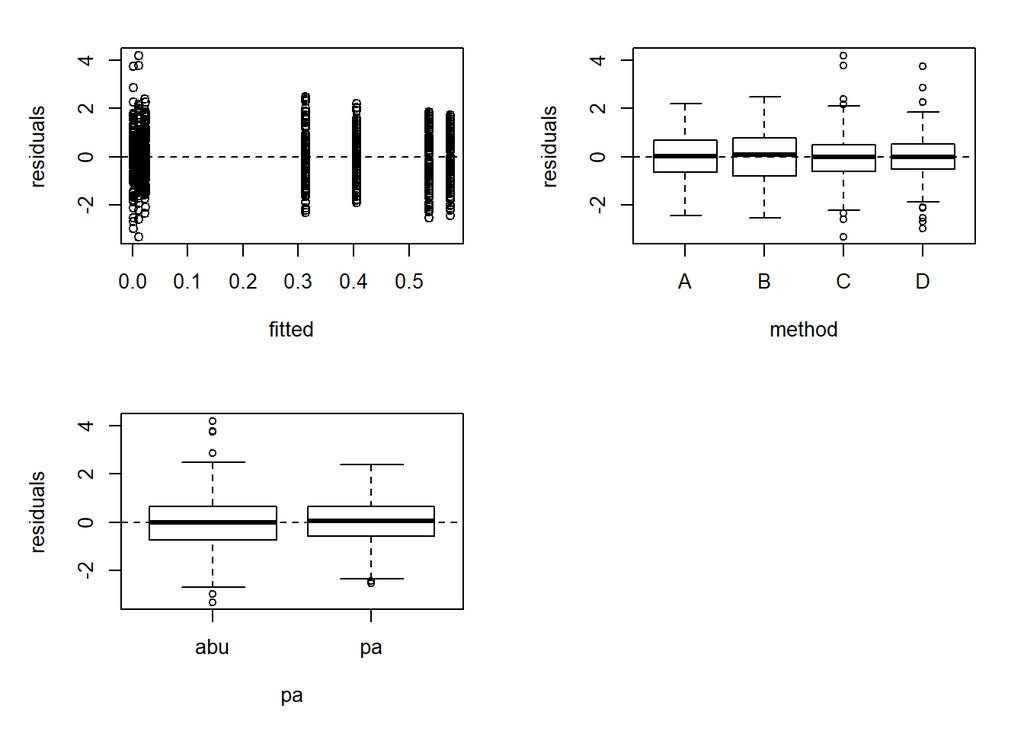

```r
E1=rstandard(m0)
F1=fitted(m0)
par(mfrow=c(2,2), mar=c(5,5,2,2))
plot(x=F1,y=E1,xlab="fitted",ylab="residuals",data=res2)
abline(h=0,lty=2)
boxplot(E1~method,xlab="method",ylab="residuals",data=res2)
abline(h=0,lty=2)
boxplot(E1~pa,xlab="pa",ylab="residuals",data=res2)
abline(h=0,lty=2)
par(mfrow=c(1,1), mar=c(5,5,2,2))
```

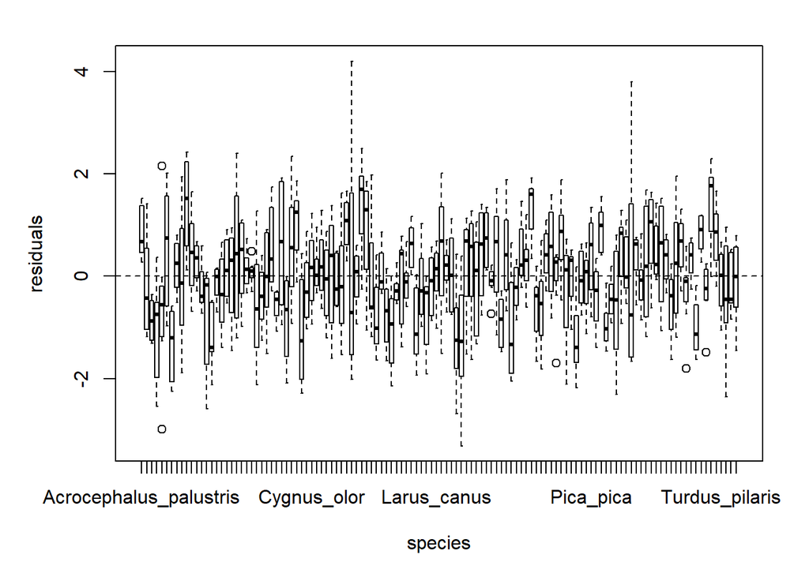

```r
boxplot(E1~species,xlab="species",ylab="residuals",data=res2)
abline(h=0,lty=2)
```

Mallin validointi paljastaa, että ‘species’ sisältää vielä vaihtelua. Se pitäisi ottaa mukaan malliin. Tehdään siis sekamalli, jossa ‘species’ on mukana random-tekijänä (120 lajia, 8 havaintoa per laji (pa/abu -aineisto + A/B/C/D -metodi)).

Laji siis random-tekijäksi mukaan. Testataan “REML”-asetuksella, kumpi on parempi.

```r
A1=gls(accuracy ~ method*pa, method="REML", data=res2,na.action="na.exclude")
A2=lme(accuracy ~ method*pa, random=~1|species, data=res2,method="REML",na.action="na.exclude")

#tai eri funktiolla (lme4)
#A2b=lmer(accuracy ~ method*pa + (1|species), data=res2,REML = T,na.action="na.exclude")

anova(A1,A2)
```

```
##    Model df       AIC       BIC   logLik   Test  L.Ratio p-value
## A1     1  9 -634.9226 -591.2335 326.4613
## A2     2 10 -776.3629 -727.8193 398.1814 1 vs 2 143.4402  <.0001
```

```r
AIC(A1,A2)
```

```
##    df       AIC
## A1  9 -634.9226
## A2 10 -776.3629
```

Sekamalli näyttäisi olevan parempi.

Muitakin random-rakenteita voisi testata. Mutta ovatko ne mielekkäitä?

Tämä [artikkeli](https://www.sciencedirect.com/science/article/pii/S0749596X12001180) neuvoo maksimoimaan random-rakenteen. Mutta artikkelin luettuani en olekaan enää ollenkaan kärryillä siitä, mitä asioita random-muuttujaksi pitäisi laittaa.

-Eikö pa-muuttuja eli aineistotyyppi voisi olla vain random-puolella? Omana interceptinään? Olisiko malli A4 maksimaalinen random-rakenne, jonka tutkimusasetelmamme sallii?

-Artikkelin esimerkissä ainoa fixed-muuttuja on se muuttuja, josta ollaan kiinnostuttu. Mitä eroa on sillä, että pa laitetaan fixed-osaan interaktioon metodin kanssa vs. pa on vain random-puolella?

```r
#muita vaihtoehtoja random-rakenteen testaamiseksi:
A3=lmer(accuracy ~ method + (1+method|species), data=res2,REML = T,na.action="na.exclude")
```

```
## boundary (singular) fit: see ?isSingular
```

```r
A4=lmer(accuracy ~ method + (1+method|species)+(1|pa), data=res2,REML = T,na.action="na.exclude")
```

```
## boundary (singular) fit: see ?isSingular
```

```r
#tämmöinenkin malli tässä oli aluksi..
#A5=lme(accuracy~method*pa,data=res2,random=~1+method*pa|species,method="REML")

AIC(A2,A3,A4)
```

```
##    df       AIC
## A2 10 -776.3629
## A3 15 -684.4331
## A4 16 -826.0481
```

Vaihtoehtoiset mallit eivät kaikki näytä toimivan. Enkä tiedä onko niissä mitään järkeä.

Keskitytään sitten fixed-osaan. Fixed-osan mallin sovituksessa käytetään “ML”-asetuksia.Tehdään neljä mallia, jotka sisältävät eri kombinaatiot muuttujista method ja pa. Vertaillaan näitä keskenään.

```r
A2full=lme(accuracy~method*pa,data=res2,random=~1|species,method="ML",na.action="na.exclude")
A2.a=lme(accuracy~method+pa,data=res2,random=~1|species,method="ML",na.action="na.exclude")
A2.b=lme(accuracy~method,data=res2,random=~1|species,method="ML",na.action="na.exclude")
A2.c=lme(accuracy~pa,data=res2,random=~1|species,method="ML",na.action="na.exclude")
A2.d=lme(accuracy ~ 1, random=~1|species, data=res2,method="ML",na.action="na.exclude")

anova(A2full,A2.a)
```

```
##        Model df       AIC       BIC   logLik   Test  L.Ratio p-value
## A2full     1 10 -829.7086 -781.0810 424.8543
## A2.a       2  7 -742.3194 -708.2801 378.1597 1 vs 2 93.38914  <.0001
```

```r
anova(A2full)
```

```
##             numDF denDF  F-value p-value
## (Intercept)     1   829 643.7077  <.0001
## method          3   829 774.4467  <.0001
## pa              1   829 135.1686  <.0001
## method:pa       3   829  32.6374  <.0001
```

```r
AIC(A2full,A2.a,A2.b,A2.c,A2.d)
```

```
##        df       AIC
## A2full 10 -829.7086
## A2.a    7 -742.3194
## A2.b    6 -630.6084
## A2.c    4  300.7516
## A2.d    3  331.1736
```

Jo ensimmäinen anova-vertailu antaa tulokseksi, että interaktio on merkitsevä, joten molemmat muuttujat ja niiden interaktio on hyvä pitää mallissa. AIC-vertailu antaa saman tuloksen.

Mietin, olisiko tässäkin kohtaa pitänyt ottaa lajien välinen fylogenia huomioon?

Lopullinen malli on siis A2full, joka ajetaan vielä kerran “REML”-asetuksilla.

```r
A2full=lme(accuracy~method*pa,data=res2,random=~1|species,method="REML",na.action="na.exclude")
summary(A2full)
```

```
## Linear mixed-effects model fit by REML
##  Data: res2
##         AIC       BIC   logLik
##   -776.3629 -727.8193 398.1814
##
## Random effects:
##  Formula: ~1 | species
##         (Intercept)  Residual
## StdDev:  0.08905381 0.1425882
##
## Fixed effects: accuracy ~ method * pa
##                   Value  Std.Error  DF    t-value p-value
## (Intercept)   0.4054711 0.01534654 829  26.421006  0.0000
## methodB      -0.0926735 0.01840805 829  -5.034401  0.0000
## methodC      -0.3948245 0.01849496 829 -21.347684  0.0000
## methodD      -0.4041154 0.01849496 829 -21.850030  0.0000
## papa          0.1694336 0.01840805 829   9.204319  0.0000
## methodB:papa  0.0533091 0.02603292 829   2.047756  0.0409
## methodC:papa -0.1568324 0.02609444 829  -6.010184  0.0000
## methodD:papa -0.1469256 0.02609444 829  -5.630531  0.0000
##  Correlation:
##              (Intr) methdB methdC methdD papa   mthdB: mthdC:
## methodB      -0.600
## methodC      -0.597  0.498
## methodD      -0.597  0.498  0.496
## papa         -0.600  0.500  0.498  0.498
## methodB:papa  0.424 -0.707 -0.352 -0.352 -0.707
## methodC:papa  0.423 -0.353 -0.709 -0.352 -0.705  0.499
## methodD:papa  0.423 -0.353 -0.352 -0.709 -0.705  0.499  0.498
##
## Standardized Within-Group Residuals:
##         Min          Q1         Med          Q3         Max
## -2.97100475 -0.60235350  0.05687203  0.62537687  4.82780782
##
## Number of Observations: 956
## Number of Groups: 120
```

```r
anova(A2full)
```

```
##             numDF denDF  F-value p-value
## (Intercept)     1   829 643.7236  <.0001
## method          3   829 774.4439  <.0001
## pa              1   829 135.1681  <.0001
## method:pa       3   829  32.6373  <.0001
```

Metodin ja data tyypin interaktio on merkitsevä.

Testailen taulukon tekemistä stargazer-paketilla:

```r
library(stargazer)
stargazer(A2full, title="Results",type="text", align=TRUE,dep.var.labels="Prediction accuracy",covariate.labels=c("method B","method C", "method D","datatype POC", "method B : datatype POC","method C: datatype POC", "method D : data type POC"))
```

```
##
## Results
## ====================================================
##                              Dependent variable:
##                          ---------------------------
##                              Prediction accuracy
## ----------------------------------------------------
## method B                          -0.093***
##                                    (0.018)
##
## method C                          -0.395***
##                                    (0.018)
##
## method D                          -0.404***
##                                    (0.018)
##
## datatype POC                      0.169***
##                                    (0.018)
##
## method B : datatype POC            0.053**
##                                    (0.026)
##
## method C: datatype POC            -0.157***
##                                    (0.026)
##
## method D : data type POC          -0.147***
##                                    (0.026)
##
## Constant                          0.405***
##                                    (0.015)
##
## ----------------------------------------------------
## Observations                         956
## Log Likelihood                     398.181
## Akaike Inf. Crit.                 -776.363
## Bayesian Inf. Crit.               -727.819
## ====================================================
## Note:                    *p<0.1; **p<0.05; ***p<0.01
```

Kokeilen testata metodien ja data tyypin välisiä eroja emmeans-paketin avulla.

```r
emmeans(A2full, list(pairwise ~ method|pa))
```

```
## $`emmeans of method | pa`
## pa = abu:
##  method  emmean     SE  df lower.CL upper.CL
##  A      0.40547 0.0153 119  0.37508   0.4359
##  B      0.31280 0.0153 119  0.28241   0.3432
##  C      0.01065 0.0155 119 -0.01995   0.0412
##  D      0.00136 0.0155 119 -0.02924   0.0319
##
## pa = pa:
##  method  emmean     SE  df lower.CL upper.CL
##  A      0.57490 0.0153 119  0.54452   0.6053
##  B      0.53554 0.0153 119  0.50515   0.5659
##  C      0.02325 0.0153 119 -0.00714   0.0536
##  D      0.02386 0.0153 119 -0.00652   0.0543
##
## Degrees-of-freedom method: containment
## Confidence level used: 0.95
##
## $`pairwise differences of method | pa`
## pa = abu:
##  contrast  estimate     SE  df t.ratio p.value
##  A - B     0.092674 0.0184 829  5.034  <.0001
##  A - C     0.394825 0.0185 829 21.348  <.0001
##  A - D     0.404115 0.0185 829 21.850  <.0001
##  B - C     0.302151 0.0185 829 16.337  <.0001
##  B - D     0.311442 0.0185 829 16.839  <.0001
##  C - D     0.009291 0.0186 829  0.500  0.9589
##
## pa = pa:
##  contrast  estimate     SE  df t.ratio p.value
##  A - B     0.039364 0.0184 829  2.138  0.1419
##  A - C     0.551657 0.0184 829 29.968  <.0001
##  A - D     0.551041 0.0184 829 29.935  <.0001
##  B - C     0.512293 0.0184 829 27.830  <.0001
##  B - D     0.511676 0.0184 829 27.796  <.0001
##  C - D    -0.000616 0.0184 829 -0.033  1.0000
##
## Degrees-of-freedom method: containment
## P value adjustment: tukey method for comparing a family of 4 estimates
```

```r
emmeans(A2full, specs=pairwise ~ method:pa)
```

```
## $emmeans
##  method pa   emmean     SE  df lower.CL upper.CL
##  A      abu 0.40547 0.0153 119  0.37508   0.4359
##  B      abu 0.31280 0.0153 119  0.28241   0.3432
##  C      abu 0.01065 0.0155 119 -0.01995   0.0412
##  D      abu 0.00136 0.0155 119 -0.02924   0.0319
##  A      pa  0.57490 0.0153 119  0.54452   0.6053
##  B      pa  0.53554 0.0153 119  0.50515   0.5659
##  C      pa  0.02325 0.0153 119 -0.00714   0.0536
##  D      pa  0.02386 0.0153 119 -0.00652   0.0543
##
## Degrees-of-freedom method: containment
## Confidence level used: 0.95
##
## $contrasts
##  contrast       estimate     SE  df t.ratio p.value
##  A,abu - B,abu  0.092674 0.0184 829   5.034 <.0001
##  A,abu - C,abu  0.394825 0.0185 829  21.348 <.0001
##  A,abu - D,abu  0.404115 0.0185 829  21.850 <.0001
##  A,abu - A,pa  -0.169434 0.0184 829  -9.204 <.0001
##  A,abu - B,pa  -0.130069 0.0184 829  -7.066 <.0001
##  A,abu - C,pa   0.382223 0.0184 829  20.764 <.0001
##  A,abu - D,pa   0.381607 0.0184 829  20.730 <.0001
##  B,abu - C,abu  0.302151 0.0185 829  16.337 <.0001
##  B,abu - D,abu  0.311442 0.0185 829  16.839 <.0001
##  B,abu - A,pa  -0.262107 0.0184 829 -14.239 <.0001
##  B,abu - B,pa  -0.222743 0.0184 829 -12.100 <.0001
##  B,abu - C,pa   0.289550 0.0184 829  15.730 <.0001
##  B,abu - D,pa   0.288934 0.0184 829  15.696 <.0001
##  C,abu - D,abu  0.009291 0.0186 829   0.500 0.9997
##  C,abu - A,pa  -0.564258 0.0185 829 -30.509 <.0001
##  C,abu - B,pa  -0.524894 0.0185 829 -28.380 <.0001
##  C,abu - C,pa  -0.012601 0.0185 829  -0.681 0.9975
##  C,abu - D,pa  -0.013217 0.0185 829  -0.715 0.9966
##  D,abu - A,pa  -0.573549 0.0185 829 -31.011 <.0001
##  D,abu - B,pa  -0.534185 0.0185 829 -28.883 <.0001
##  D,abu - C,pa  -0.021892 0.0185 829  -1.184 0.9365
##  D,abu - D,pa  -0.022508 0.0185 829  -1.217 0.9269
##  A,pa - B,pa    0.039364 0.0184 829   2.138 0.3910
##  A,pa - C,pa    0.551657 0.0184 829  29.968 <.0001
##  A,pa - D,pa    0.551041 0.0184 829  29.935 <.0001
##  B,pa - C,pa    0.512293 0.0184 829  27.830 <.0001
##  B,pa - D,pa    0.511676 0.0184 829  27.796 <.0001
##  C,pa - D,pa   -0.000616 0.0184 829  -0.033 1.0000
##
## Degrees-of-freedom method: containment
## P value adjustment: tukey method for comparing a family of 8 estimates
```

```r
emm2 = emmeans(A2full, specs = pairwise ~ method|pa, adjust="bonferroni")
emm2
```

```
## $emmeans
## pa = abu:
##  method  emmean     SE  df lower.CL upper.CL
##  A      0.40547 0.0153 119   0.3665   0.4444
##  B      0.31280 0.0153 119   0.2739   0.3517
##  C      0.01065 0.0155 119  -0.0285   0.0498
##  D      0.00136 0.0155 119  -0.0378   0.0405
##
## pa = pa:
##  method  emmean     SE  df lower.CL upper.CL
##  A      0.57490 0.0153 119   0.5360   0.6138
##  B      0.53554 0.0153 119   0.4966   0.5745
##  C      0.02325 0.0153 119  -0.0157   0.0622
##  D      0.02386 0.0153 119  -0.0151   0.0628
##
## Degrees-of-freedom method: containment
## Confidence level used: 0.95
## Conf-level adjustment: bonferroni method for 4 estimates
##
## $contrasts
## pa = abu:
##  contrast  estimate     SE  df t.ratio p.value
##  A - B     0.092674 0.0184 829  5.034  <.0001
##  A - C     0.394825 0.0185 829 21.348  <.0001
##  A - D     0.404115 0.0185 829 21.850  <.0001
##  B - C     0.302151 0.0185 829 16.337  <.0001
##  B - D     0.311442 0.0185 829 16.839  <.0001
##  C - D     0.009291 0.0186 829  0.500  1.0000
##
## pa = pa:
##  contrast  estimate     SE  df t.ratio p.value
##  A - B     0.039364 0.0184 829  2.138  0.1966
##  A - C     0.551657 0.0184 829 29.968  <.0001
##  A - D     0.551041 0.0184 829 29.935  <.0001
##  B - C     0.512293 0.0184 829 27.830  <.0001
##  B - D     0.511676 0.0184 829 27.796  <.0001
##  C - D    -0.000616 0.0184 829 -0.033  1.0000
##
## Degrees-of-freedom method: containment
## P value adjustment: bonferroni method for 6 tests
```

```r
emm3 = emmeans(A2full, specs =pairwise ~ pa|method, adjust="bonferroni")
emm3
```

```
## $emmeans
## method = A:
##  pa   emmean     SE  df lower.CL upper.CL
##  abu 0.40547 0.0153 119   0.3706   0.4403
##  pa  0.57490 0.0153 119   0.5401   0.6097
##
## method = B:
##  pa   emmean     SE  df lower.CL upper.CL
##  abu 0.31280 0.0153 119   0.2780   0.3476
##  pa  0.53554 0.0153 119   0.5007   0.5704
##
## method = C:
##  pa   emmean     SE  df lower.CL upper.CL
##  abu 0.01065 0.0155 119  -0.0244   0.0457
##  pa  0.02325 0.0153 119  -0.0116   0.0581
##
## method = D:
##  pa   emmean     SE  df lower.CL upper.CL
##  abu 0.00136 0.0155 119  -0.0337   0.0364
##  pa  0.02386 0.0153 119  -0.0110   0.0587
##
## Degrees-of-freedom method: containment
## Confidence level used: 0.95
## Conf-level adjustment: bonferroni method for 2 estimates
##
## $contrasts
## method = A:
##  contrast estimate     SE  df t.ratio p.value
##  abu - pa  -0.1694 0.0184 829  -9.204 <.0001
##
## method = B:
##  contrast estimate     SE  df t.ratio p.value
##  abu - pa  -0.2227 0.0184 829 -12.100 <.0001
##
## method = C:
##  contrast estimate     SE  df t.ratio p.value
##  abu - pa  -0.0126 0.0185 829  -0.681 0.4959
##
## method = D:
##  contrast estimate     SE  df t.ratio p.value
##  abu - pa  -0.0225 0.0185 829  -1.217 0.2240
##
## Degrees-of-freedom method: containment
```

Tulokset mietityttävät koska tämän testin mukaan pa-aineistolla metodit A ja B sekä C ja D eivät eroa toisistaan. Seuraavassa osiossa teen t-testejä mielestäni samalla tavalla (bonferroni), mutta tulokset ovat erilaiset. Mielestäni nämä tulokset vaikuttavat järkevämmiltä, ainakin kun katsoo luottamusvälejä ja niiden päällekkäisyyksiä.

Abu-aineistolla vain C ja D metodit eivät eroa toisistaan.

Mallin validointi residuaalien avulla:

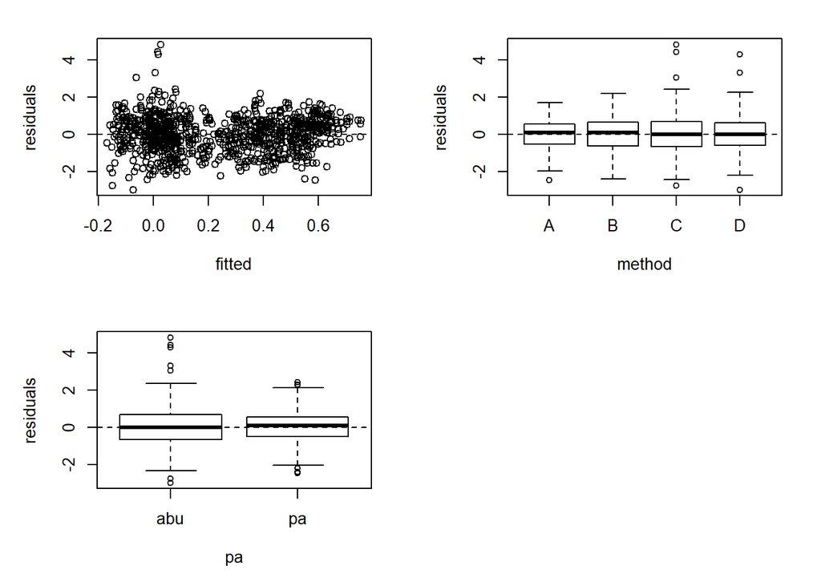

```r
E1=resid(A2full, type="normalized")
F1=fitted(A2full)
par(mfrow=c(2,2), mar=c(5,5,2,2))
plot(x=F1,y=E1,xlab="fitted",ylab="residuals",data=res2)
abline(h=0,lty=2)
boxplot(E1~method,xlab="method",ylab="residuals",data=res2)
abline(h=0,lty=2)
boxplot(E1~pa,xlab="pa",ylab="residuals",data=res2)
abline(h=0,lty=2)
par(mfrow=c(1,1), mar=c(5,5,2,2))
```

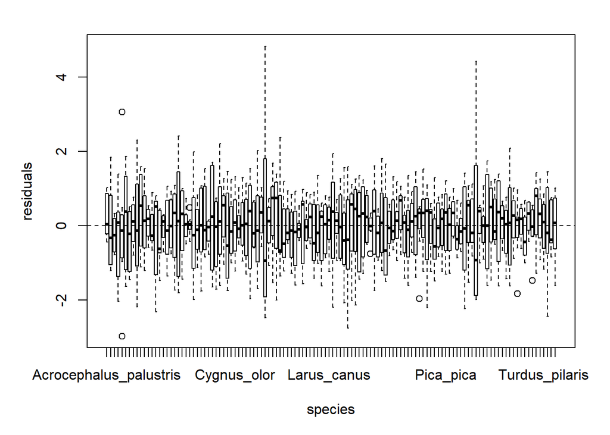

```r
boxplot(E1~species,xlab="species",ylab="residuals",data=res2)
abline(h=0,lty=2)
```

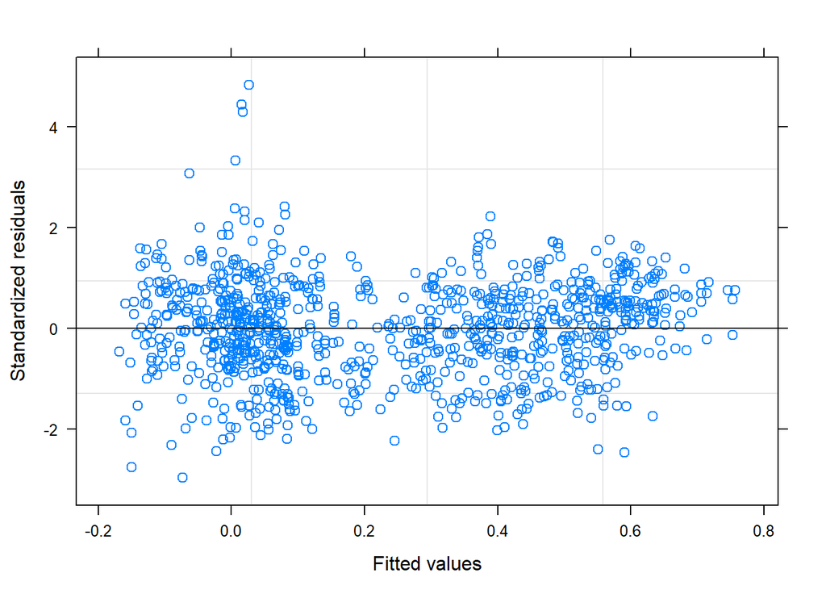

```r
plot(A2full)
```

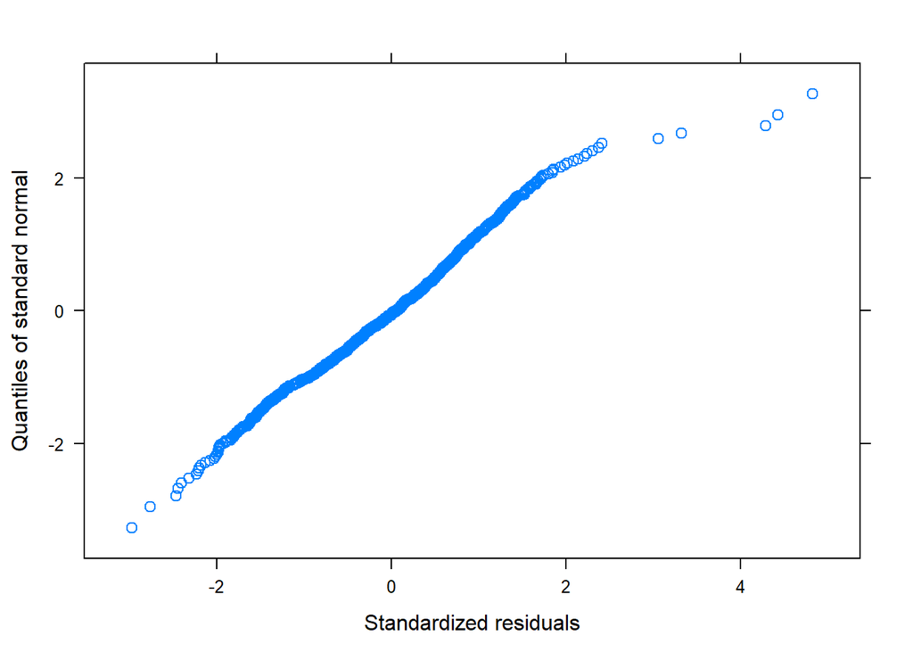

```r
qqnorm(A2full)
```

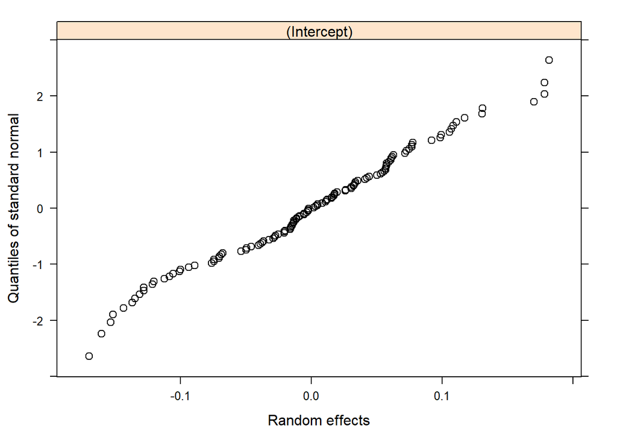

```r
qqnorm(A2full,~ranef(.),col=1)
```

```r
intervals(A2full)
```

```
## Approximate 95% confidence intervals
##
##  Fixed effects:
##                     lower        est.       upper
## (Intercept)   0.375348482  0.40547113  0.43559379
## methodB      -0.128805417 -0.09267354 -0.05654166
## methodC      -0.431126998 -0.39482454 -0.35852209
## methodD      -0.440417857 -0.40411540 -0.36781295
## papa          0.133301739  0.16943362  0.20556549
## methodB:papa  0.002210881  0.05330907  0.10440727
## methodC:papa -0.208051371 -0.15683242 -0.10561347
## methodD:papa -0.198144537 -0.14692559 -0.09570664
## attr(,"label")
## [1] "Fixed effects:"
##
##  Random Effects:
##   Level: species
##                      lower       est.     upper
## sd((Intercept)) 0.07521711 0.08905381 0.1054359
##
##  Within-group standard error:
##     lower      est.     upper
## 0.1358864 0.1425882 0.1496205
```

Eli ennustustarkkuuteen vaikuttavat metodin ja aineiston yhdistelmä. Residuaalit näyttävät ihan ok:lta.

### 2.2.3 ANOVA, pairwise t-tests

Vaihtoehtoinen analyysi. Kokeilen kaikenlaista huvin ja hyödyn vuoksi.

```r
#stats
res2 %>%
  group_by(method,pa)%>%
  get_summary_stats(accuracy, type = "mean_sd")
```

```
## # A tibble: 8 x 6
##   method pa    variable     n  mean    sd
##   <fct>  <fct> <chr>    <dbl> <dbl> <dbl>
## 1 A      abu   accuracy   120 0.405 0.163
## 2 A      pa    accuracy   120 0.575 0.168
## 3 B      abu   accuracy   120 0.313 0.187
## 4 B      pa    accuracy   120 0.536 0.18
## 5 C      abu   accuracy   118 0.012 0.185
## 6 C      pa    accuracy   120 0.023 0.14
## 7 D      abu   accuracy   118 0.003 0.18
## 8 D      pa    accuracy   120 0.024 0.135
```

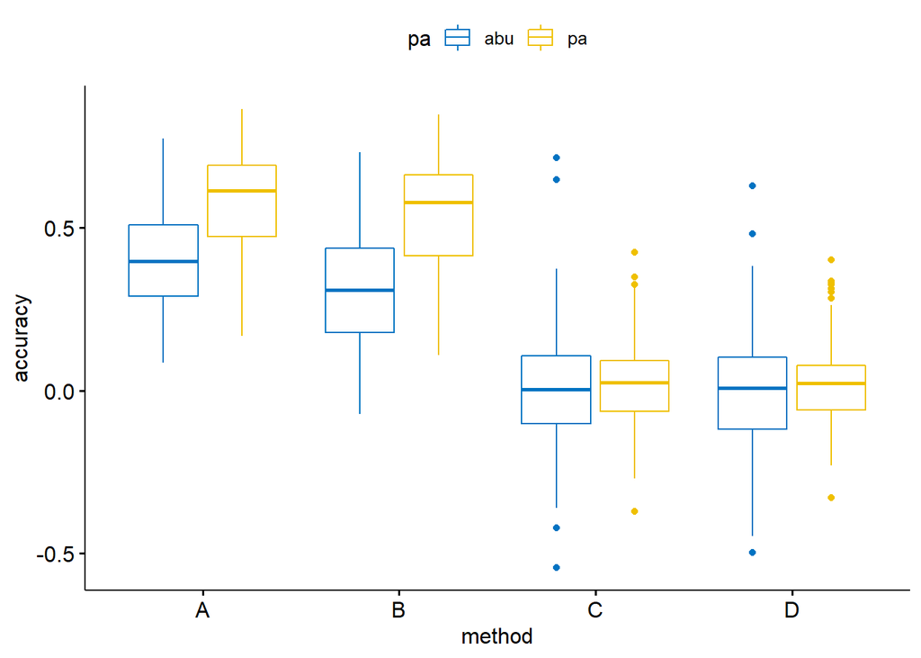

```r
#visualization
bxp <- ggboxplot(
  res2, x = "method", y = "accuracy",
  color = "pa", palette = "jco"
  )
bxp
```

```r
#outliers
res2 %>%
  group_by(method,pa) %>%
  identify_outliers(accuracy)
```

```
## # A tibble: 20 x 6
##    method pa    species                  accuracy is.outlier is.extreme
##    <fct>  <fct> <fct>                       <dbl> <lgl>      <lgl>
##  1 C      abu   Aythya_fuligula            -0.421 TRUE       FALSE
##  2 C      abu   Falco_tinnunculus           0.714 TRUE       FALSE
##  3 C      abu   Lullula_arborea            -0.543 TRUE       FALSE
##  4 C      abu   Scolopax_rusticola          0.647 TRUE       FALSE
##  5 C      pa    Anser_anser                 0.348 TRUE       FALSE
##  6 C      pa    Carduelis_carduelis         0.425 TRUE       FALSE
##  7 C      pa    Turdus_merula               0.326 TRUE       FALSE
##  8 C      pa    Turdus_torquatus           -0.371 TRUE       FALSE
##  9 D      abu   Aegithalos_caudatus        -0.497 TRUE       FALSE
## 10 D      abu   Falco_tinnunculus           0.629 TRUE       FALSE
## 11 D      abu   Scolopax_rusticola          0.480 TRUE       FALSE
## 12 D      pa    Anser_anser                 0.325 TRUE       FALSE
## 13 D      pa    Carduelis_carduelis         0.401 TRUE       FALSE
## 14 D      pa    Columba_livia               0.282 TRUE       FALSE
## 15 D      pa    Fringilla_coelebs           0.335 TRUE       FALSE
## 16 D      pa    Fringilla_montifringilla    0.333 TRUE       FALSE
## 17 D      pa    Parus_major                 0.283 TRUE       FALSE
## 18 D      pa    Phasianus_colchicus        -0.328 TRUE       FALSE
## 19 D      pa    Turdus_merula               0.313 TRUE       FALSE
## 20 D      pa    Turdus_philomelos           0.303 TRUE       FALSE
```

```r
#normality
res2 %>%
  group_by(method,pa) %>%
  shapiro_test(accuracy)
```

```
## # A tibble: 8 x 5
##   method pa    variable statistic       p
##   <fct>  <fct> <chr>        <dbl>   <dbl>
## 1 A      abu   accuracy     0.985 0.197
## 2 A      pa    accuracy     0.970 0.00928
## 3 B      abu   accuracy     0.987 0.325
## 4 B      pa    accuracy     0.967 0.00502
## 5 C      abu   accuracy     0.964 0.00328
## 6 C      pa    accuracy     0.992 0.683
## 7 D      abu   accuracy     0.985 0.219
## 8 D      pa    accuracy     0.977 0.0369
```

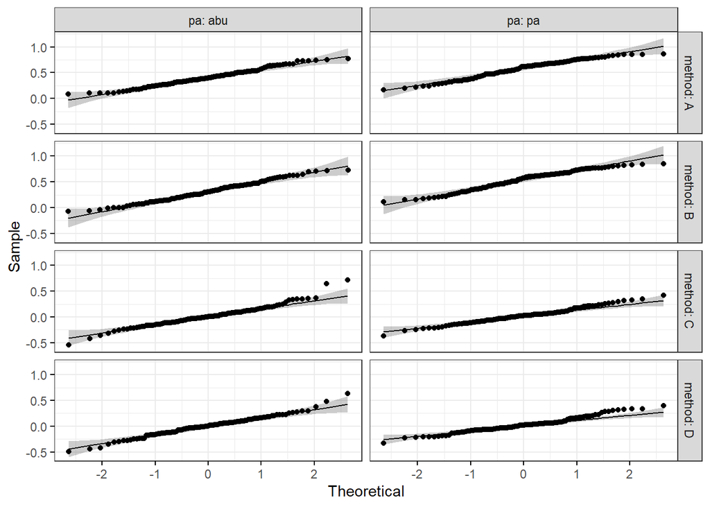

```r
#qqplot
ggqqplot(res2, "accuracy", ggtheme = theme_bw()) +
  facet_grid(method ~ pa, labeller = "label_both")
```

Ei kai kummempaa aineistossa. Outliereitä paljon testin mukaan. Ei kuitenkaan aivan ekstreemejä. En toistaiseksi käyttänyt liikaa aikaa näiden tulkitsemiseen.

```r
#the test
res.aov <- anova_test(
  data = res2, dv = accuracy, wid = species,
  within = c(pa, method)
  )
get_anova_table(res.aov)
```

```
## ANOVA Table (type III tests)
##
##      Effect  DFn    DFd       F        p p<.05   ges
## 1        pa 1.00 117.00  83.961 2.03e-15     * 0.091
## 2    method 1.24 145.03 691.293 1.96e-62     * 0.640
## 3 pa:method 1.35 158.24  44.180 2.68e-12     * 0.068
```

Data tyyppi (pa) ja method-interaktio merkitsevä.

```r
# Effect of method at both data types
one.way <- res2 %>%
  group_by(pa) %>%
  anova_test(dv = accuracy, wid = species, within = method) %>%
  get_anova_table() %>%
  adjust_pvalue(method = "bonferroni")
one.way
```

```
## # A tibble: 2 x 9
##   pa    Effect   DFn   DFd     F        p `p<.05`   ges    p.adj
##   <fct> <chr>  <dbl> <dbl> <dbl>    <dbl> <chr>   <dbl>    <dbl>
## 1 abu   method  1.44  169.  231. 3.04e-41 *       0.507 6.08e-41
## 2 pa    method  1.08  128.  758. 2.00e-57 *       0.745 4.00e-57
```

Metodit eroavat toisistaan kummallakin aineistotyypillä.

Mitkä metodit eroavat toisistaan?

```r
# Pairwise comparisons between methods
pwc <- res2 %>%
  group_by(pa) %>%
  pairwise_t_test(
    accuracy ~ method, paired = TRUE,
    p.adjust.method = "bonferroni"
    )
pwc
```

```
## # A tibble: 12 x 11
##    pa    .y.   group1 group2    n1    n2 statistic    df        p    p.adj
##  * <fct> <chr> <chr>  <chr>  <int> <int>     <dbl> <dbl>    <dbl>    <dbl>
##  1 abu   accu~ A      B        120   120    15.9     119 3.99e-31 2.39e-30
##  2 abu   accu~ A      C        120   120    17.4     117 3.60e-34 2.16e-33
##  3 abu   accu~ A      D        120   120    18.9     117 2.35e-37 1.41e-36
##  4 abu   accu~ B      C        120   120    12.7     117 1.03e-23 6.18e-23
##  5 abu   accu~ B      D        120   120    14.2     117 3.41e-27 2.05e-26
##  6 abu   accu~ C      D        120   120     0.702   117 4.84e- 1 1.00e+ 0
##  7 pa    accu~ A      B        120   120    15.2     119 1.20e-29 7.20e-29
##  8 pa    accu~ A      C        120   120    28.7     119 2.22e-55 1.33e-54
##  9 pa    accu~ A      D        120   120    30.1     119 1.61e-57 9.66e-57
## 10 pa    accu~ B      C        120   120    25.6     119 3.73e-50 2.24e-49
## 11 pa    accu~ B      D        120   120    26.9     119 1.77e-52 1.06e-51
## 12 pa    accu~ C      D        120   120    -0.128   119 8.98e- 1 1.00e+ 0
## # ... with 1 more variable: p.adj.signif <chr>
```

```r
# Pairwise comparisons between data types
pwc <- res2 %>%
  group_by(method) %>%
  pairwise_t_test(
    accuracy ~ pa, paired = TRUE,
    p.adjust.method = "bonferroni"
    )
pwc
```

```
## # A tibble: 4 x 11
##   method .y.   group1 group2    n1    n2 statistic    df        p    p.adj
## * <fct>  <chr> <chr>  <chr>  <int> <int>     <dbl> <dbl>    <dbl>    <dbl>
## 1 A      accu~ abu    pa       120   120   -14.2     119 1.93e-27 1.93e-27
## 2 B      accu~ abu    pa       120   120   -16.2     119 7.99e-32 7.99e-32
## 3 C      accu~ abu    pa       120   120    -0.556   117 5.80e- 1 5.80e- 1
## 4 D      accu~ abu    pa       120   120    -1.08    117 2.82e- 1 2.82e- 1
## # ... with 1 more variable: p.adj.signif <chr>
```

sama tulos kuin yllä koska vain kaksi data tyyppiä.

```r
# Effect of pa at each method
one.way <- res2 %>%
  group_by(method) %>%
  anova_test(dv = accuracy, wid = species, within = pa) %>%
  get_anova_table() %>%
  adjust_pvalue(method = "bonferroni")
one.way
```

```
## # A tibble: 4 x 9
##   method Effect   DFn   DFd       F        p `p<.05`   ges    p.adj
##   <fct>  <chr>  <dbl> <dbl>   <dbl>    <dbl> <chr>   <dbl>    <dbl>
## 1 A      pa         1   119 202.    1.93e-27 *       0.21  7.72e-27
## 2 B      pa         1   119 262.    7.99e-32 *       0.271 3.20e-31
## 3 C      pa         1   117   0.309 5.80e- 1 ""      0.001 1.00e+ 0
## 4 D      pa         1   117   1.17  2.82e- 1 ""      0.005 1.00e+ 0
```

Simple main effect of data type (pa) was significant for all other methods except for C and D.

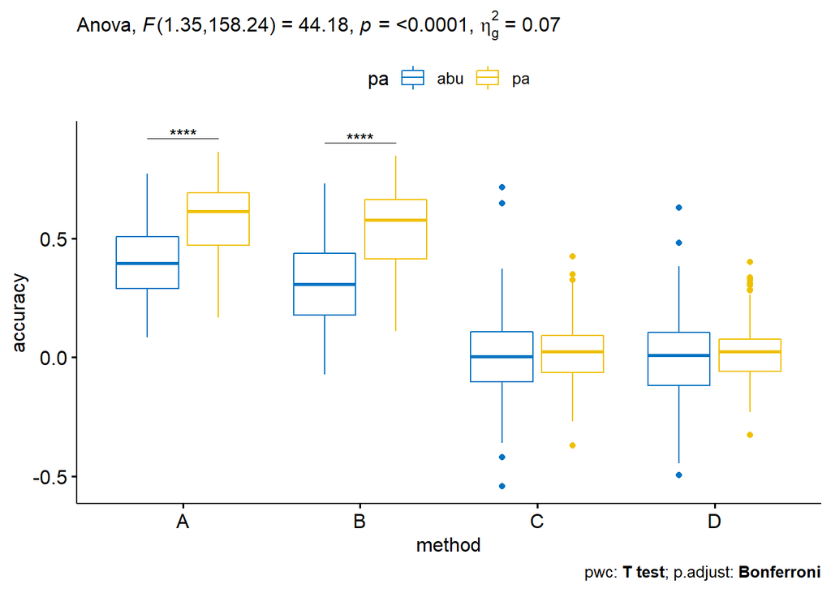

```r
# Visualization: box plots with p-values
pwc <- pwc %>% add_xy_position(x = "method")
bxp +
  stat_pvalue_manual(pwc, tip.length = 0, hide.ns = TRUE) +
  labs(
    subtitle = get_test_label(res.aov, detailed = TRUE),
    caption = get_pwc_label(pwc)
  )
```

## 2.3 Muita kuvaajia

### 2.3.1 Boxplotti

Perus boxplottikuvaaja:

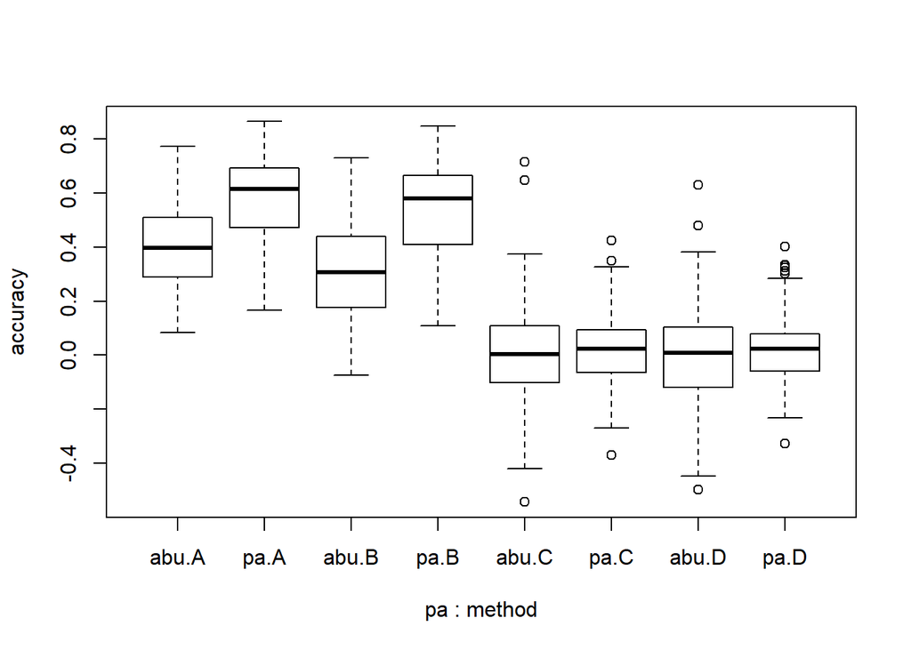

```r
boxplot(accuracy~pa*method,data=res2)
```

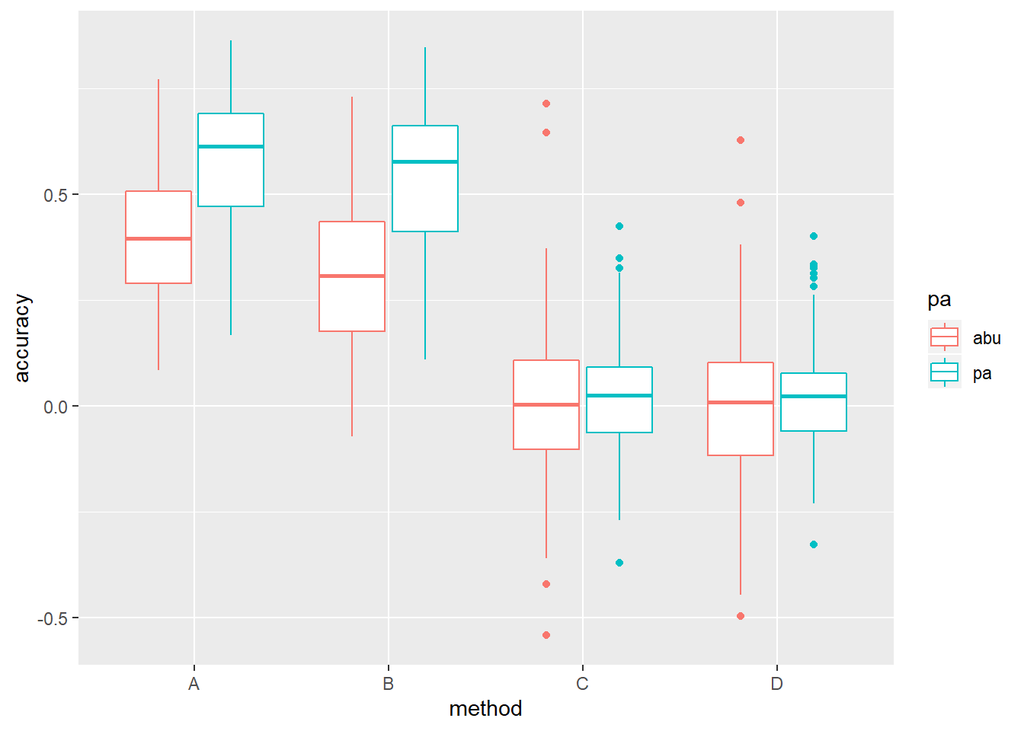

```r
ggplot(res2, aes(x = method, y = accuracy, interaction = pa, colour = pa)) + geom_boxplot()
```

### 2.3.2 Kahden metodin korrelaatioplotti

Alkuperäinen idea kuvaajasta oli tämä:

```r
# Piirretään kuvaaja, Fig1

#määritetään kuvalle raamit ja nimi
Line=c(-1,1)
Line2=c(-1,1)
Line3=c(0,0)

Line=cbind(Line,Line2)
Line=cbind(Line,Line3)

Line=as.data.frame(Line)

#pdf("Fig123.pdf")
jpeg("Fig123.jpeg")
#png("Fig1abcdef.png")

#määrittää 3x3 matriisin johon kuvat piirretään
layout(matrix(c(1,2,7,3,4,7,5,6,7), 3, 3, byrow = TRUE))

# a)
plot(pa_B~pa_A,data=res,xlim=c(-1,1),
     ylim=c(-1,1),cex.axis=0.8,xlab="Prediction accuracy (A)",
     ylab="Prediction accuracy (B)")
lines(Line$Line,Line$Line2,lty="dashed")
lines(Line$Line,Line$Line3,col="grey",lty="dashed")
lines(Line$Line3,Line$Line,col="grey",lty="dashed")

text(-0.5,0.8,"a) Distribution",cex=0.8)

# b)
plot(abu_B~abu_A,data=res,xlim=c(-1,1),
     ylim=c(-1,1),cex.axis=0.8,xlab="Prediction accuracy (A)",
     ylab="Prediction accuracy (B)")
lines(Line$Line,Line$Line2,lty="dashed")
lines(Line$Line,Line$Line3,col="grey",lty="dashed")
lines(Line$Line3,Line$Line,col="grey",lty="dashed")

text(-0.5,0.8,"b) Abundance",cex=0.8)

# c)
plot(pa_D~pa_C,data=res,xlim=c(-1,1),
     ylim=c(-1,1),cex.axis=0.8,xlab="Prediction accuracy (C)",
     ylab="Prediction accuracy (D)")
lines(Line$Line,Line$Line2,lty="dashed")
lines(Line$Line,Line$Line3,col="grey",lty="dashed")
lines(Line$Line3,Line$Line,col="grey",lty="dashed")

text(-0.5,0.8,"c) Distribution",cex=0.8)

# d)
plot(abu_D~abu_C,data=res,xlim=c(-1,1),
     ylim=c(-1,1),cex.axis=0.8,xlab="Prediction accuracy (C)",
     ylab="Prediction accuracy (D)")
lines(Line$Line,Line$Line2,lty="dashed")
lines(Line$Line,Line$Line3,col="grey",lty="dashed")
lines(Line$Line3,Line$Line,col="grey",lty="dashed")

text(-0.5,0.8,"d) Abundance",cex=0.8)

#dev.off()
```

En saa kuvaajaa näkymään tässä mutta se löytyy kässäristä.

Tätä pitäisi vielä miettiä, mitä plotataan ja mitä vasten? Alun perin verrattiin metodi D:tä pa/abu_past-arvoihin eli vähän sama kuin vertailu metodi A:han. siis, voitaisiinko jo hyvin yksinkertaisella validointimenetelmällä saada samoja tuloksia kuin monimutkaisemmalla metodilla?

### 2.3.3 Luottamusvälit

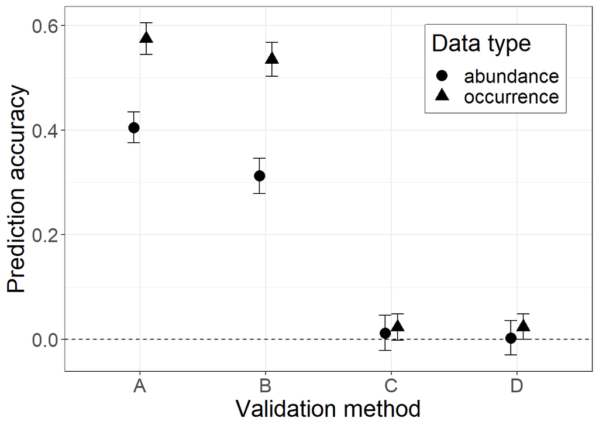

```r
library(Rmisc)
stat <- summarySE(res2, measurevar="accuracy", groupvars=c("method","pa"),na.rm = T)
stat
stat$lower=stat$accuracy-stat$ci
stat$upper=stat$accuracy+stat$ci
round(stat[,4:9],digits = 3)
names(res2)[4] <- "Data_type"
names(stat)[2] <- "Data_type"

pd <- position_dodge(0.2) # move them .05 to the left and right

# Black error bars - notice the mapping of 'group=supp' -- without it, the error
# bars won't be dodged!
#ggplot(stat, aes(x=method, y=accuracy, group=Data_type)) +
#    geom_errorbar(aes(ymin=accuracy-ci, ymax=accuracy+ci), colour="black", width=.2, position=pd) +
#    geom_point(aes(shape=Data_type),position=pd, size=4)+
#    scale_shape_manual(values=c(19,17))+
#    scale_fill_discrete(name = "Data type", labels = c("abu", "POC"))+
#    ylab("Prediction accuracy") +
#    xlab("Validation method") +
#    theme_bw() +
#    theme(legend.justification=c(1,1),
#          legend.position=c(0.95,0.95),
#          legend.box.background=element_rect())  +             # Position legend in bottom right
#    theme(text = element_text(size = 20))


ggplot(stat, aes(y=accuracy, x=method,shape=Data_type))+
  ylab("Prediction accuracy") +
    xlab("Validation method") +
  geom_errorbar(aes(ymin=accuracy-ci, ymax=accuracy+ci), colour="black", width=.2, position=pd)+
    theme_bw() +
    theme(legend.justification=c(1,1),
          legend.position=c(0.95,0.95),
          legend.box.background=element_rect())  +             # Position legend in bottom right
    theme(text = element_text(size = 20)) +
    geom_point(position=pd, size=4,fill="white") +
  scale_shape_discrete(name = "Data type", labels = c("abundance", "occurrence"))+geom_hline(yintercept=0,linetype="dashed")
```

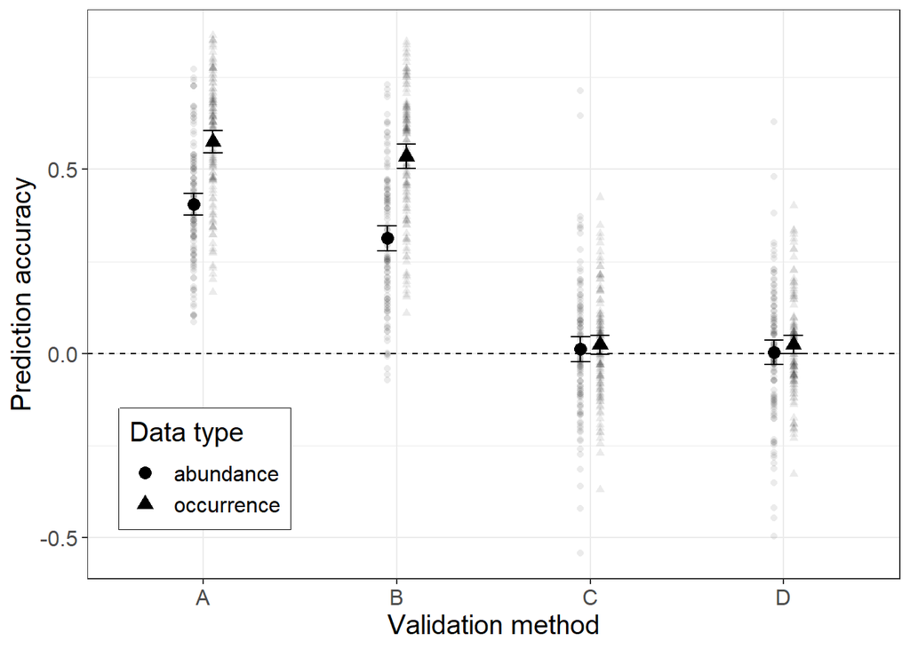

```r
ggsave("plot1_simple.png")
ggplot(stat, aes(y=accuracy, x=method,shape=Data_type))+
  ylab("Prediction accuracy") +
    xlab("Validation method") +
  geom_errorbar(aes(ymin=accuracy-ci, ymax=accuracy+ci), colour="black", width=.2, position=pd)+
    theme_bw() +
    theme(legend.justification=c(1,1),
          legend.position=c(0.25,0.30),
          legend.box.background=element_rect())  +             # Position legend in bottom right
    theme(text = element_text(size = 15)) +
    geom_point(position=pd, size=3,fill="white") +
  scale_shape_discrete(name = "Data type", labels = c("abundance", "occurrence"))+geom_hline(yintercept=0,linetype="dashed")+
  geom_point(data=res2, position=pd, alpha=0.08)
```

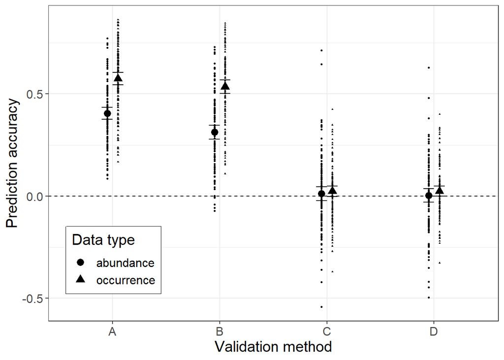

```r
ggsave("plot1_alpha.png")
ggplot(stat, aes(y=accuracy, x=method,shape=Data_type))+
  ylab("Prediction accuracy") +
    xlab("Validation method") +
  geom_errorbar(aes(ymin=accuracy-ci, ymax=accuracy+ci), colour="black", width=.2, position=pd)+
    theme_bw() +
    theme(legend.justification=c(1,1),
          legend.position=c(0.25,0.30),
          legend.box.background=element_rect())  +             # Position legend in bottom right
    theme(text = element_text(size = 15)) +
    geom_point(position=pd, size=3,fill="white") +
  scale_shape_discrete(name = "Data type", labels = c("abundance", "occurrence"))+geom_hline(yintercept=0,linetype="dashed")+
  geom_point(data=res2, position=pd, size=0.5)
```

```r
ggsave("plot1_noalpha.png")
```